# Exercise 12.13

Kári Hlynsson

April 2024

On the book website, `www.statlearning.com`, there is a gene expression data set (`Ch12Ex13.csv`) that consists of 40 tissue samples with measurements on 1,000 genes. The first 20 samples are from healthy patients, while the second 20 are from a diseased group.

## Part (a)

Load in the data using `read.csv()`. You will need to select `header = F`.

```r
tmp <- tempfile()
download.file(
  url = "https://www.statlearning.com/s/Ch12Ex13.csv",
  dest = tmp
)
x <- t(read.csv(tmp, header = FALSE))
rm(tmp)

# 1 = healthy, 2 = diseased
status <- c(rep(1, 20), rep(2, 20))
```

Data cleaning:

```r
rownames(x) <- paste0("P", 1:40)
colnames(x) <- paste0("G", 1:1000)
```

Let’s compute some summary statistics to infer whether scaling is necessary:

```r
apply(x, 2, mean) |> range()
```

```
## [1] -0.5619419  1.4757837
```

Variances:

```r
apply(x, 2, var) |> range()
```

```
## [1] 0.4229844 3.1610329
```

Close enough – I don’t think scaling is necessary.

## Part (b)

Apply hierarchical clustering to the samples using correlation-based distance, and plot the dendrogram. Do the genes separate the samples in to the two groups? Do your results depend on the type of linkage used?

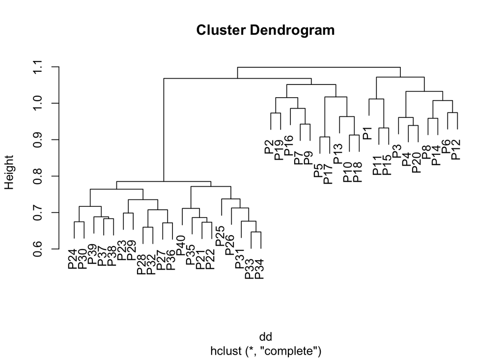

```r
dd <- as.dist(1 - cor(t(x)))

dclust <- function(link) {
  xclust <- hclust(dd, method = link)
  plot(xclust)

  pred <- cutree(xclust, 2)

  return(table(pred, status))
}

cl_complete <- dclust("complete")
```

Split dendrogram based on the two groups:

```r
cl_complete
```

```
##     status
## pred  1  2
##    1 10  0
##    2 10 20
```

The hierarchical clustering correctly identifies all diseased patients, but confuses almost half the healthy patients in case of complete linkage. Let’s try single linkage.

```r
cl_single <- dclust("single")
```

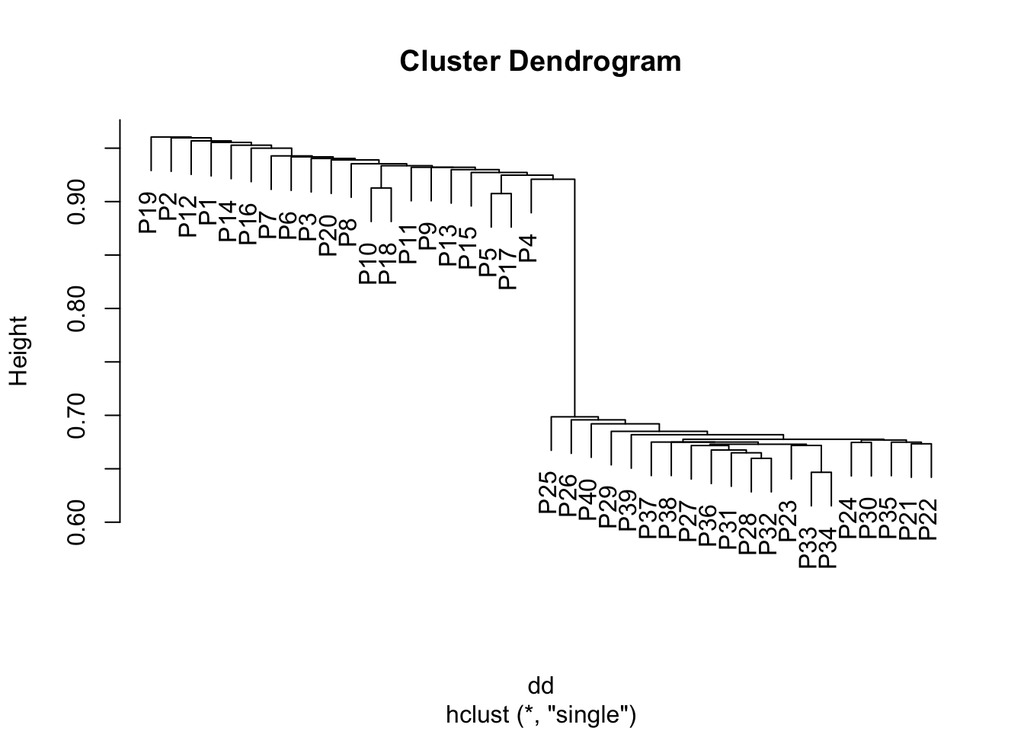

```r
cl_single
```

```
##     status
## pred  1  2
##    1 19 20
##    2  1  0
```

Single linkage is better in terms of identifying healthy patients, but abysmal when it comes to identifying diseased patients – in fact, it has a 100% error rate when it comes to identifying them.

Average linkage:

```r
cl_average <- dclust("average")
```

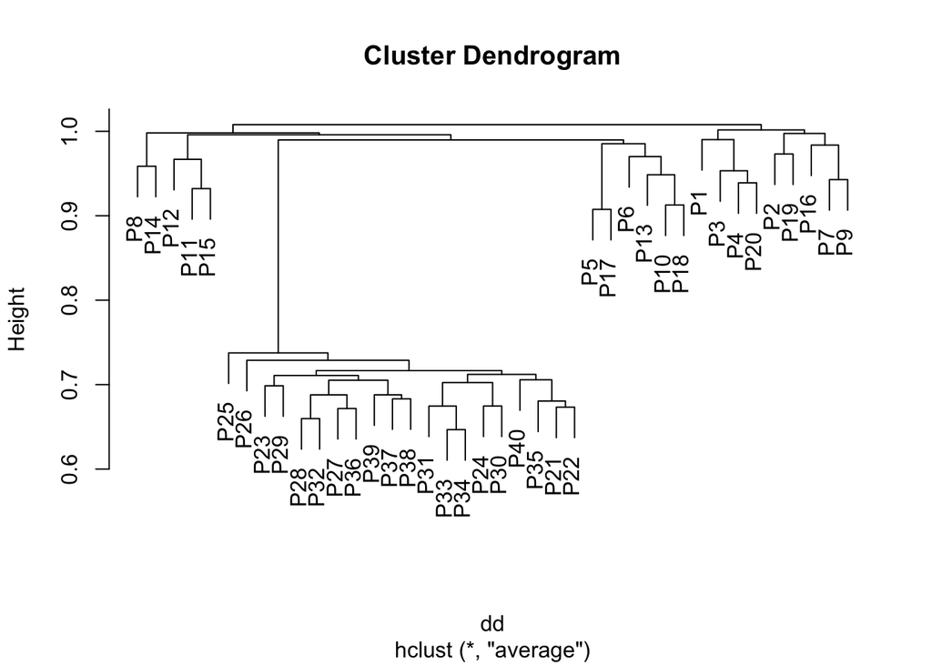

```r
cl_average
```

```
##     status
## pred  1  2
##    1  9  0
##    2 11 20
```

Similar but slightly worse performance to the complete linkage clustering.

Lastly, we have centroid linkage:

```r
cl_centroid <- dclust("centroid")
```

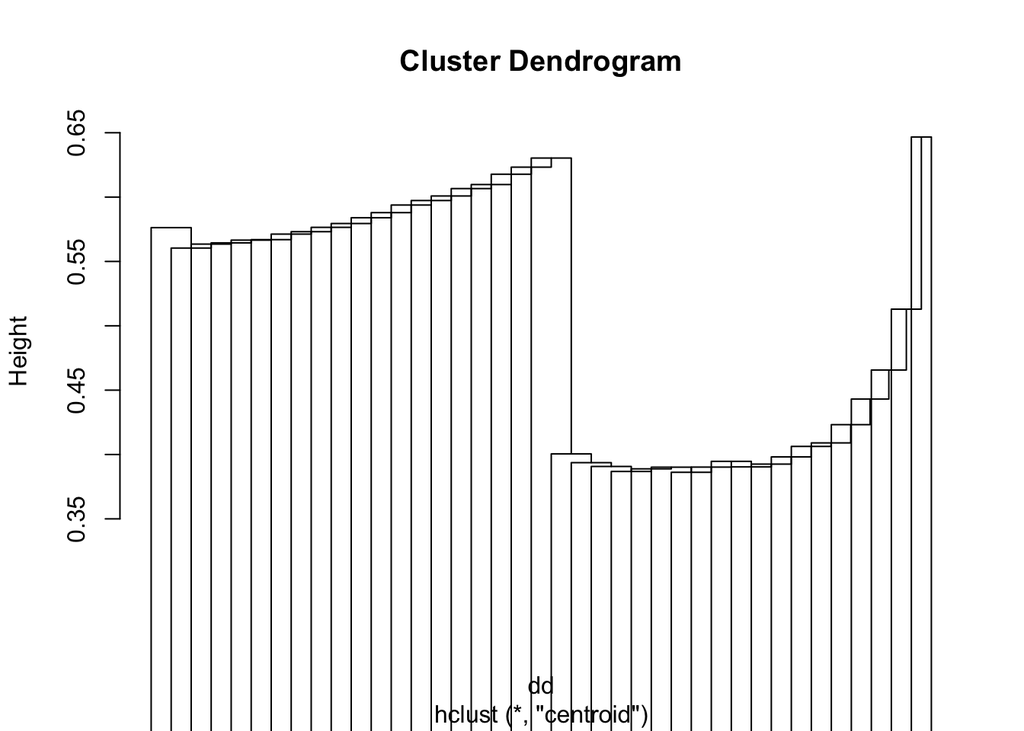

```r
cl_centroid
```

```
##     status
## pred  1  2
##    1  1  0
##    2 19 20
```

Terrible. Complete linkage turned out to be the best method.

## Part (c)

Your collaborator wants to know which genes differ the most across the two groups. Suggest a way to answer this question, and apply it here.

As seen in (b), using hierarchical clustering with completel linkage yielded the best results where 100% of diseased patients were correctly identified. However, healthy patients were often misclassified which is not so good.

We might want to test whether we can use PCA to identify genes central to the expression of disease status. I.e., if the principal components divide the two groups visually, we might be in luck. Let’s try it out:

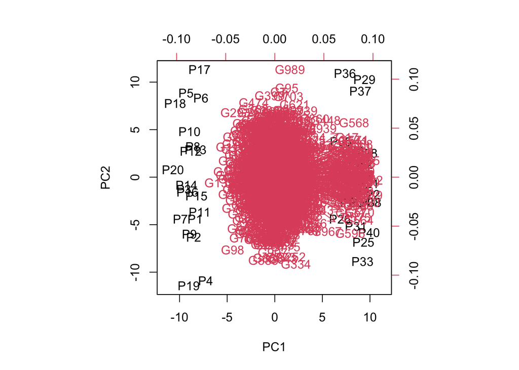

```r
pr <- prcomp(x, scale = TRUE)

biplot(pr, scale = 0)
```

Although the principal components are fairly indecisive, there appears to be some division in the data when projected onto the principal component score values – might these be our groups?

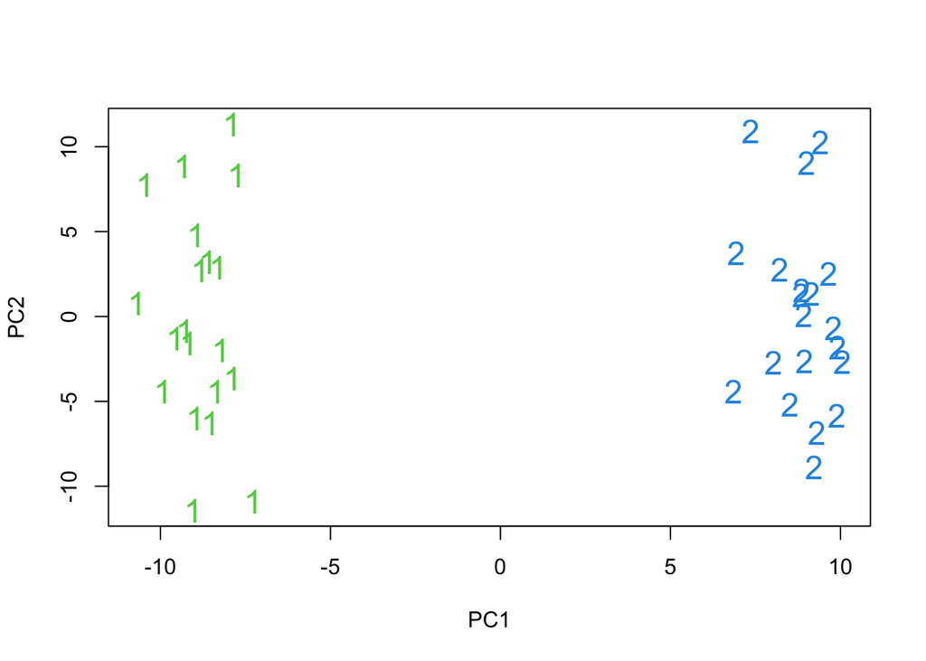

```r
plot(pr$x[, 1], pr$x[, 2], pch = paste(status), col = status + 2, cex = 1.5,
     xlab = "PC1", ylab = "PC2")
```

Jackpot! We can classify the patients in terms of gene expression using the first principal component:

```r
pred_pca <- ifelse(pr$x[, 1] > 0, 2, 1)

table(pred_pca, status)
```

```
##         status
## pred_pca  1  2
##        1 20  0
##        2  0 20
```

Yippee!